# MLB Umpire Pitch-Call Analysis

Ty Curtis

2026-08-14

# Overview

This project analyzes MLB umpire accuracy on called balls and strikes using pitch-level Statcast data. The analysis first examines the 2025 MLB season and then expands across the 2015–2025 regular seasons to evaluate changes in missed-call rates over time and identify teams most affected by incorrect ball/strike calls.

## Setup

```r
library(baseballr)
library(tidyverse)
```

# 2025 MLB Season

## Collect Statcast Data

Statcast data are collected one day at a time for the 2025 MLB season and combined into a single dataset. The resulting data are cached locally so the full dataset does not need to be downloaded repeatedly.

```r
dates_2025 <- seq.Date(
  as.Date("2025-03-27"),
  as.Date("2025-09-28"),
  by = "day"
)

pull_one_day <- function(date) {
  message("Pulling: ", date)

  url <- paste0(
    "https://baseballsavant.mlb.com/statcast_search/csv?",
    "all=true&hfGT=R%7CPO%7CS%7C&hfSea=2025%7C",
    "&player_type=pitcher",
    "&game_date_gt=", date,
    "&game_date_lt=", date,
    "&min_pitches=0&min_results=0",
    "&group_by=name",
    "&sort_col=pitches",
    "&player_event_sort=h_launch_speed",
    "&sort_order=desc",
    "&min_abs=0",
    "&type=details"
  )

  tryCatch(
    read_csv(url, show_col_types = FALSE, col_types = cols(.default = col_character())) %>%
      mutate(source_date = as.character(date)),
    error = function(e) {
      message("FAILED: ", date)
      tibble()
    }
  )
}

statcast_2025 <- map_dfr(dates_2025, pull_one_day)
```

[output not shown]

[output not shown]

[output not shown]

[output not shown]

[output not shown]

[output not shown]

[output not shown]

[output not shown]

[output not shown]

[output not shown]

[output not shown]

[output not shown]

[output not shown]

[output not shown]

[output not shown]

[output not shown]

[output not shown]

[output not shown]

[output not shown]

[output not shown]

[output not shown]

[output not shown]

[output not shown]

[output not shown]

[output not shown]

[output not shown]

[output not shown]

[output not shown]

[output not shown]

[output not shown]

[output not shown]

[output not shown]

[output not shown]

[output not shown]

[output not shown]

[output not shown]

[output not shown]

[output not shown]

[output not shown]

[output not shown]

[output not shown]

[output not shown]

[output not shown]

[output not shown]

[output not shown]

[output not shown]

[output not shown]

[output not shown]

[output not shown]

[output not shown]

[output not shown]

[output not shown]

[output not shown]

[output not shown]

[output not shown]

[output not shown]

[output not shown]

[output not shown]

[output not shown]

[output not shown]

[output not shown]

[output not shown]

[output not shown]

[output not shown]

[output not shown]

[output not shown]

[output not shown]

[output not shown]

[output not shown]

[output not shown]

[output not shown]

[output not shown]

[output not shown]

[output not shown]

[output not shown]

[output not shown]

[output not shown]

[output not shown]

[output not shown]

[output not shown]

[output not shown]

[output not shown]

[output not shown]

[output not shown]

[output not shown]

[output not shown]

[output not shown]

[output not shown]

[output not shown]

[output not shown]

[output not shown]

[output not shown]

[output not shown]

[output not shown]

[output not shown]

[output not shown]

[output not shown]

[output not shown]

[output not shown]

[output not shown]

[output not shown]

[output not shown]

[output not shown]

[output not shown]

[output not shown]

[output not shown]

[output not shown]

[output not shown]

[output not shown]

[output not shown]

[output not shown]

[output not shown]

[output not shown]

[output not shown]

[output not shown]

[output not shown]

[output not shown]

[output not shown]

[output not shown]

[output not shown]

[output not shown]

[output not shown]

[output not shown]

[output not shown]

[output not shown]

[output not shown]

[output not shown]

[output not shown]

[output not shown]

[output not shown]

[output not shown]

[output not shown]

[output not shown]

[output not shown]

[output not shown]

[output not shown]

[output not shown]

[output not shown]

[output not shown]

[output not shown]

[output not shown]

[output not shown]

[output not shown]

[output not shown]

[output not shown]

[output not shown]

[output not shown]

[output not shown]

[output not shown]

[output not shown]

[output not shown]

[output not shown]

[output not shown]

[output not shown]

[output not shown]

[output not shown]

[output not shown]

[output not shown]

[output not shown]

[output not shown]

[output not shown]

[output not shown]

[output not shown]

[output not shown]

[output not shown]

[output not shown]

[output not shown]

[output not shown]

[output not shown]

[output not shown]

[output not shown]

[output not shown]

[output not shown]

[output not shown]

[output not shown]

[output not shown]

[output not shown]

[output not shown]

[output not shown]

[output not shown]

[output not shown]

[output not shown]

[output not shown]

[output not shown]

[output not shown]

[output not shown]

```r
saveRDS(statcast_2025, "statcast_2025_raw.rds")
```

## Classify Called Pitches

Only pitches recorded as called strikes or balls are retained. Pitch location and the batter-specific vertical strike-zone boundaries are used to classify whether each pitch was actually inside the strike zone.

That classification is then compared with the umpire’s recorded call.

```r
called_2025 <- statcast_2025 %>%
  filter(description %in% c("called_strike", "ball")) %>%
  mutate(
    plate_x = as.numeric(plate_x),
    plate_z = as.numeric(plate_z),
    sz_top = as.numeric(sz_top),
    sz_bot = as.numeric(sz_bot),

    actual_strike = plate_x >= -0.83 & plate_x <= 0.83 &
      plate_z >= sz_bot & plate_z <= sz_top,

    umpire_called_strike = description == "called_strike",
    correct_call = actual_strike == umpire_called_strike
  )

called_2025 %>%
  summarise(
    total_called_pitches = n(),
    missed_calls = sum(!correct_call, na.rm = TRUE),
    miss_rate = mean(!correct_call, na.rm = TRUE)
  )
```

```
## # A tibble: 1 × 3
##   total_called_pitches missed_calls miss_rate
##                  <int>        <int>     <dbl>
## 1               353473        27075    0.0766
```

## Determine Which Team Was Harmed

Incorrect calls are separated into strikes called balls and balls called strikes. The batting and fielding teams are then used to identify which team was negatively affected by each missed call.

```r
called_2025_clean <- called_2025 %>%
  mutate(
    batting_team = if_else(inning_topbot == "Top", away_team, home_team),
    fielding_team = if_else(inning_topbot == "Top", home_team, away_team),

    miss_type = case_when(
      actual_strike == TRUE  & umpire_called_strike == FALSE ~ "Missed strike called ball",
      actual_strike == FALSE & umpire_called_strike == TRUE  ~ "Missed ball called strike",
      TRUE ~ "Correct"
    ),

    team_harmed = case_when(
      miss_type == "Missed strike called ball" ~ fielding_team,
      miss_type == "Missed ball called strike" ~ batting_team,
      TRUE ~ NA_character_
    )
  )
```

## Teams Most Affected by Missed Calls

```r
team_unlucky <- called_2025_clean %>%
  filter(!correct_call) %>%
  count(team_harmed, sort = TRUE) %>%
  mutate(missed_calls_against_per_100 = n / sum(n) * 100)

team_unlucky
```

```
## # A tibble: 30 × 3
##    team_harmed     n missed_calls_against_per_100
##    <chr>       <int>                        <dbl>
##  1 LAA          1011                         3.73
##  2 CWS           979                         3.62
##  3 LAD           978                         3.61
##  4 PIT           976                         3.60
##  5 NYY           969                         3.58
##  6 CIN           956                         3.53
##  7 MIL           941                         3.48
##  8 MIN           940                         3.47
##  9 SF            936                         3.46
## 10 WSH           934                         3.45
## # ℹ 20 more rows
```

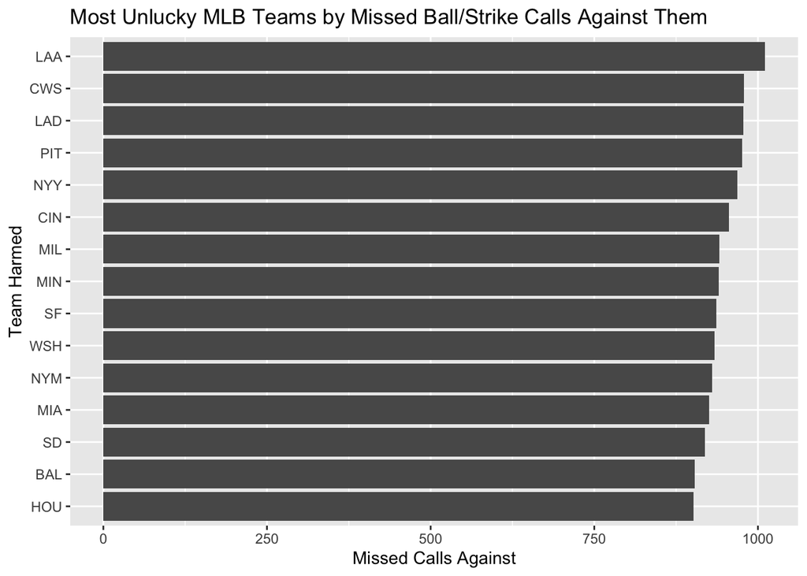

```r
team_unlucky %>%
  slice_max(n, n = 15) %>%
  ggplot(aes(x = reorder(team_harmed, n), y = n)) +
  geom_col() +
  coord_flip() +
  labs(
    title = "Most Unlucky MLB Teams by Missed Ball/Strike Calls Against Them",
    x = "Team Harmed",
    y = "Missed Calls Against"
  )
```

## Called Pitches by Umpire

```r
called_2025_clean %>%
  count(umpire, sort = TRUE)
```

```
## # A tibble: 1 × 2
##   umpire      n
##   <chr>   <int>
## 1 <NA>   353473
```

## 2025 Umpire Miss Rate

The overall miss rate is expressed as the number of incorrect ball/strike calls per 100 called pitches.

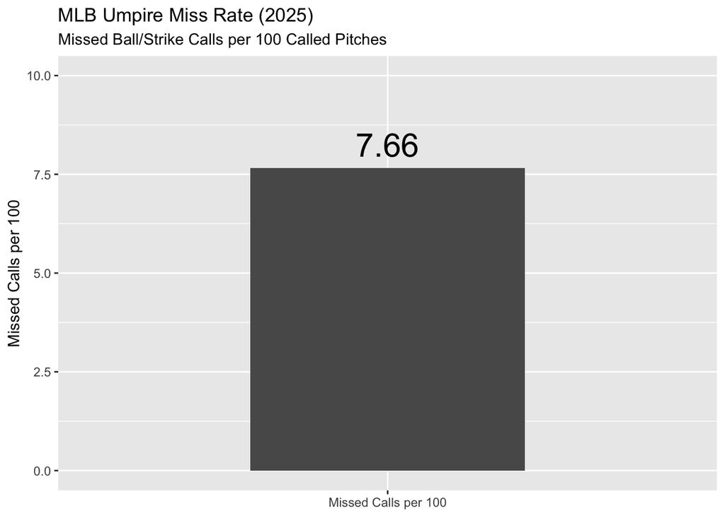

```r
summary_df <- tibble(
  metric = "Missed Calls per 100",
  value = 100 * mean(!called_2025$correct_call, na.rm = TRUE)
)

ggplot(summary_df, aes(x = metric, y = value)) +
  geom_col(width = 0.5) +
  geom_text(
    aes(label = round(value, 2)),
    vjust = -0.5,
    size = 8
  ) +
  labs(
    title = "MLB Umpire Miss Rate (2025)",
    subtitle = "Missed Ball/Strike Calls per 100 Called Pitches",
    x = NULL,
    y = "Missed Calls per 100"
  ) +
  ylim(0, 10)
```

## Overall Called-Pitch Accuracy

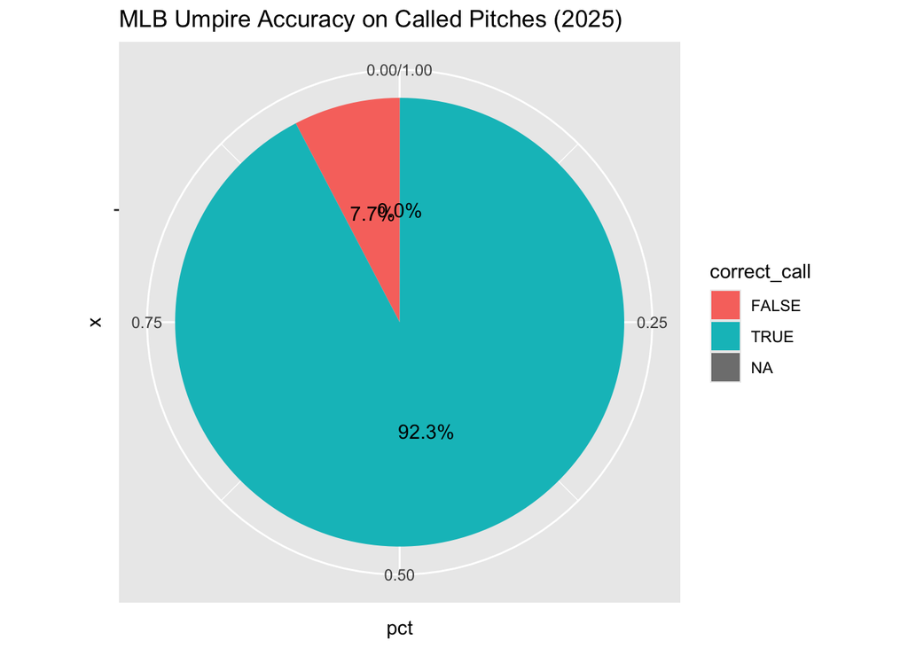

```r
called_2025 %>%
  count(correct_call) %>%
  mutate(
    pct = n / sum(n)
  ) %>%
  ggplot(aes(
    x = "",
    y = pct,
    fill = correct_call
  )) +
  geom_col(width = 1) +
  coord_polar(theta = "y") +
  geom_text(
    aes(label = scales::percent(pct)),
    position = position_stack(vjust = 0.5)
  ) +
  labs(
    title = "MLB Umpire Accuracy on Called Pitches (2025)"
  )
```

## Average Missed Calls per Game

```r
missed_per_game <- called_2025 %>%
  filter(!is.na(game_pk), !is.na(correct_call)) %>%
  group_by(game_pk) %>%
  summarise(
    missed_calls = sum(!correct_call),
    .groups = "drop"
  )

avg_missed_per_game <- mean(missed_per_game$missed_calls)

avg_missed_per_game
```

```
## [1] 11.15115
```

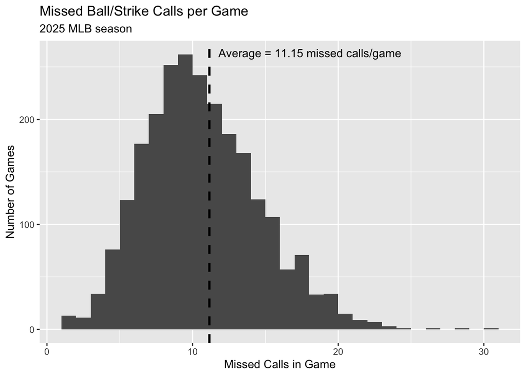

```r
missed_per_game %>%
  ggplot(aes(x = missed_calls)) +
  geom_histogram(binwidth = 1, boundary = 0) +
  geom_vline(xintercept = avg_missed_per_game, linetype = "dashed", linewidth = 1) +
  annotate(
    "text",
    x = avg_missed_per_game,
    y = Inf,
    label = paste0("Average = ", round(avg_missed_per_game, 2), " missed calls/game"),
    vjust = 2,
    hjust = -0.05
  ) +
  labs(
    title = "Missed Ball/Strike Calls per Game",
    subtitle = "2025 MLB season",
    x = "Missed Calls in Game",
    y = "Number of Games"
  )
```

# MLB Umpire Accuracy: 2015–2025

The analysis is expanded to the 2015–2025 MLB regular seasons to examine whether ball/strike accuracy has changed over time.

## Collect Multi-Season Statcast Data

```r
library(tidyverse)

years_to_pull <- 2015:2025

pull_one_day <- function(date, year) {
  message("Pulling: ", date)

  url <- paste0(
    "https://baseballsavant.mlb.com/statcast_search/csv?",
    "all=true",
    "&hfGT=R%7C",
    "&hfSea=", year, "%7C",
    "&player_type=pitcher",
    "&game_date_gt=", date,
    "&game_date_lt=", date,
    "&min_pitches=0",
    "&min_results=0",
    "&group_by=name",
    "&sort_col=pitches",
    "&player_event_sort=h_launch_speed",
    "&sort_order=desc",
    "&min_abs=0",
    "&type=details"
  )

  tryCatch(
    read_csv(url, show_col_types = FALSE, col_types = cols(.default = col_character())) %>%
      select(any_of(c(
        "game_date", "game_year", "game_pk",
        "description", "plate_x", "plate_z", "sz_top", "sz_bot",
        "inning_topbot", "home_team", "away_team"
      ))) %>%
      mutate(source_date = as.character(date), year = year),
    error = function(e) {
      message("FAILED: ", date)
      tibble()
    }
  )
}

pull_one_year <- function(year) {
  file_name <- paste0("statcast_", year, "_called_raw.rds")

  if (file.exists(file_name)) {
    message("Loading cached ", year)
    return(readRDS(file_name))
  }

  dates <- seq.Date(
    as.Date(paste0(year, "-03-01")),
    as.Date(paste0(year, "-11-15")),
    by = "day"
  )

  year_data <- map_dfr(dates, ~pull_one_day(.x, year))
  saveRDS(year_data, file_name)
  year_data
}

statcast_all <- map_dfr(years_to_pull, pull_one_year)
```

```
## Loading cached 2015
```

```
## Loading cached 2016
```

```
## Loading cached 2017
```

```
## Loading cached 2018
```

```
## Loading cached 2019
```

```
## Loading cached 2020
```

```
## Loading cached 2021
```

```
## Loading cached 2022
```

```
## Loading cached 2023
```

```
## Loading cached 2024
```

```
## Loading cached 2025
```

```r
saveRDS(statcast_all, "statcast_2015_2025_raw.rds")
```

## Clean and Classify Called Pitches

The same strike-zone classification used for the 2025 analysis is applied consistently across all seasons.

```r
called_all <- statcast_all %>%
  filter(description %in% c("called_strike", "ball")) %>%
  mutate(
    year = as.integer(year),
    game_pk = as.character(game_pk),
    plate_x = as.numeric(plate_x),
    plate_z = as.numeric(plate_z),
    sz_top = as.numeric(sz_top),
    sz_bot = as.numeric(sz_bot),

    actual_strike = plate_x >= -0.83 & plate_x <= 0.83 &
      plate_z >= sz_bot & plate_z <= sz_top,

    umpire_called_strike = description == "called_strike",
    correct_call = actual_strike == umpire_called_strike,

    batting_team = if_else(inning_topbot == "Top", away_team, home_team),
    fielding_team = if_else(inning_topbot == "Top", home_team, away_team),

    miss_type = case_when(
      actual_strike == TRUE  & umpire_called_strike == FALSE ~ "Strike called ball",
      actual_strike == FALSE & umpire_called_strike == TRUE  ~ "Ball called strike",
      TRUE ~ "Correct"
    ),

    team_harmed = case_when(
      miss_type == "Strike called ball" ~ fielding_team,
      miss_type == "Ball called strike" ~ batting_team,
      TRUE ~ NA_character_
    )
  ) %>%
  filter(!is.na(correct_call))

saveRDS(called_all, "called_pitches_2015_2025_clean.rds")
```

# Results

## Missed Calls per 100 Called Pitches

The first comparison measures the number of missed ball/strike calls per 100 called pitches for each MLB season.

```r
year_summary <- called_all %>%
  group_by(year) %>%
  summarise(
    total_called_pitches = n(),
    missed_calls = sum(!correct_call),
    missed_per_100 = 100 * missed_calls / total_called_pitches,
    .groups = "drop"
  )

year_summary
```

```
## # A tibble: 11 × 4
##     year total_called_pitches missed_calls missed_per_100
##    <int>                <int>        <int>          <dbl>
##  1  2015               350885        38525          11.0
##  2  2016               360208        37919          10.5
##  3  2017               363685        35768           9.83
##  4  2018               362584        33744           9.31
##  5  2019               364045        34448           9.46
##  6  2020               134242        12661           9.43
##  7  2021               353246        31583           8.94
##  8  2022               350896        30372           8.66
##  9  2023               358480        30143           8.41
## 10  2024               351858        29810           8.47
## 11  2025               353710        27098           7.66
```

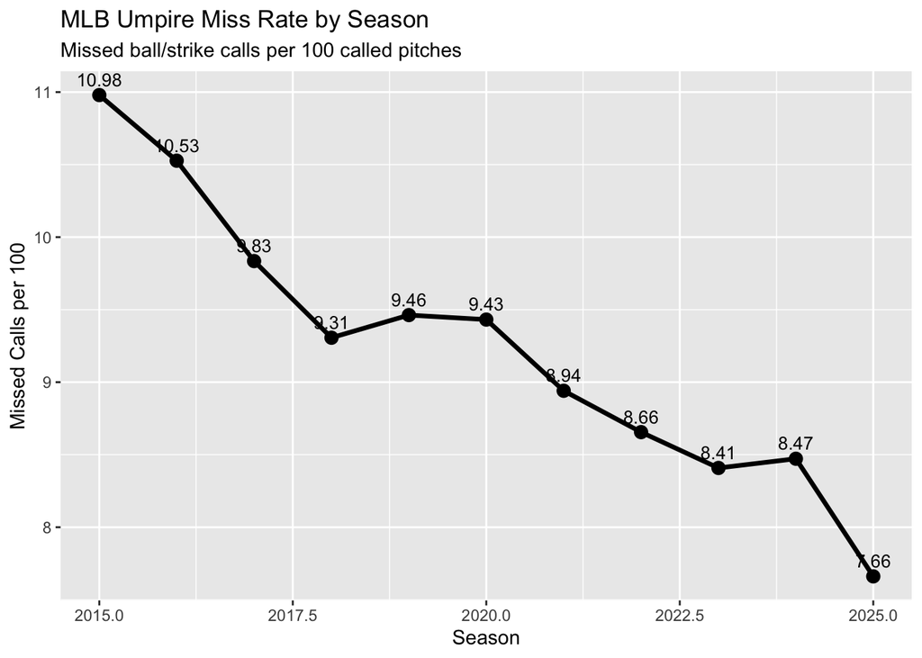

```r
ggplot(year_summary, aes(x = year, y = missed_per_100)) +
  geom_line(linewidth = 1.2) +
  geom_point(size = 3) +
  geom_text(
    aes(label = round(missed_per_100, 2)),
    vjust = -0.7,
    size = 3.5
  ) +
  labs(
    title = "MLB Umpire Miss Rate by Season",
    subtitle = "Missed ball/strike calls per 100 called pitches",
    x = "Season",
    y = "Missed Calls per 100"
  )
```

## Average Missed Calls per Game

The second comparison measures how many incorrect ball/strike calls occurred in the average MLB game during each season.

```r
missed_per_game_year <- called_all %>%
  group_by(year, game_pk) %>%
  summarise(
    missed_calls = sum(!correct_call),
    .groups = "drop"
  ) %>%
  group_by(year) %>%
  summarise(
    games = n(),
    avg_missed_calls_per_game = mean(missed_calls),
    .groups = "drop"
  )

missed_per_game_year
```

```
## # A tibble: 11 × 3
##     year games avg_missed_calls_per_game
##    <int> <int>                     <dbl>
##  1  2015  2429                      15.9
##  2  2016  2428                      15.6
##  3  2017  2428                      14.7
##  4  2018  2426                      13.9
##  5  2019  2415                      14.3
##  6  2020   898                      14.1
##  7  2021  2427                      13.0
##  8  2022  2429                      12.5
##  9  2023  2430                      12.4
## 10  2024  2429                      12.3
## 11  2025  2430                      11.2
```

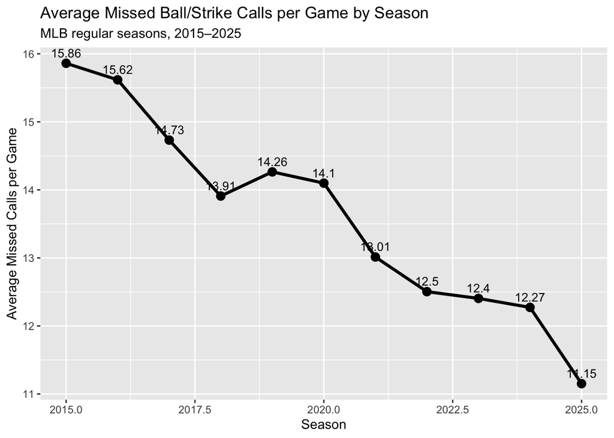

```r
ggplot(missed_per_game_year, aes(x = year, y = avg_missed_calls_per_game)) +
  geom_line(linewidth = 1.2) +
  geom_point(size = 3) +
  geom_text(
    aes(label = round(avg_missed_calls_per_game, 2)),
    vjust = -0.7,
    size = 3.5
  ) +
  labs(
    title = "Average Missed Ball/Strike Calls per Game by Season",
    subtitle = "MLB regular seasons, 2015–2025",
    x = "Season",
    y = "Average Missed Calls per Game"
  )
```

## Teams Most Affected by Missed Calls

Finally, missed calls are attributed to the team harmed by the decision. Teams are ranked within each season according to the total number of incorrect ball/strike calls against them.

```r
team_unlucky_by_year <- called_all %>%
  filter(!correct_call, !is.na(team_harmed)) %>%
  group_by(year, team_harmed) %>%
  summarise(
    missed_calls_against = n(),
    .groups = "drop"
  ) %>%
  group_by(year) %>%
  mutate(rank = min_rank(desc(missed_calls_against))) %>%
  ungroup()

team_unlucky_by_year
```

```
## # A tibble: 330 × 4
##     year team_harmed missed_calls_against  rank
##    <int> <chr>                      <int> <int>
##  1  2015 ATH                         1472     2
##  2  2015 ATL                         1411     5
##  3  2015 AZ                          1272    13
##  4  2015 BAL                         1168    29
##  5  2015 BOS                         1377     6
##  6  2015 CHC                         1337     8
##  7  2015 CIN                         1447     3
##  8  2015 CLE                         1302    11
##  9  2015 COL                         1240    17
## 10  2015 CWS                         1191    27
## # ℹ 320 more rows
```

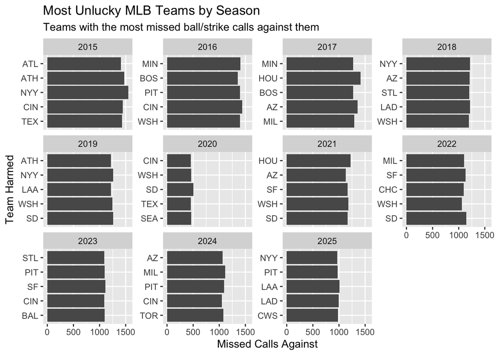

```r
team_unlucky_by_year %>%
  filter(rank <= 5) %>%
  ggplot(aes(
    x = reorder(team_harmed, missed_calls_against),
    y = missed_calls_against
  )) +
  geom_col() +
  coord_flip() +
  facet_wrap(~ year, scales = "free_y") +
  labs(
    title = "Most Unlucky MLB Teams by Season",
    subtitle = "Teams with the most missed ball/strike calls against them",
    x = "Team Harmed",
    y = "Missed Calls Against"
  )
```

## Most Affected Team by Season

```r
team_unlucky_by_year %>%
  filter(rank == 1) %>%
  arrange(year)
```

```
## # A tibble: 12 × 4
##     year team_harmed missed_calls_against  rank
##    <int> <chr>                      <int> <int>
##  1  2015 NYY                         1552     1
##  2  2016 CIN                         1436     1
##  3  2017 HOU                         1415     1
##  4  2018 NYY                         1218     1
##  5  2019 NYY                         1259     1
##  6  2019 SD                          1259     1
##  7  2020 SD                           502     1
##  8  2021 HOU                         1224     1
##  9  2022 SD                          1149     1
## 10  2023 SF                          1109     1
## 11  2024 MIL                         1115     1
## 12  2025 LAA                         1011     1
```